# HSE Subgroup Analysis

This notebook contains analysis of adults (16 year old and above) from the 2019 Health Survey for England sample. Sample weights have been applied to all analysis. The purpose of this analysis is to gain an initial understanding of the profiles of individuals living with excess weight (overweight or obese) in England.

# Excess Weight Prevalence

Overall, 35.5% of the adult population is classified as overweight, and 28.2% as obese.

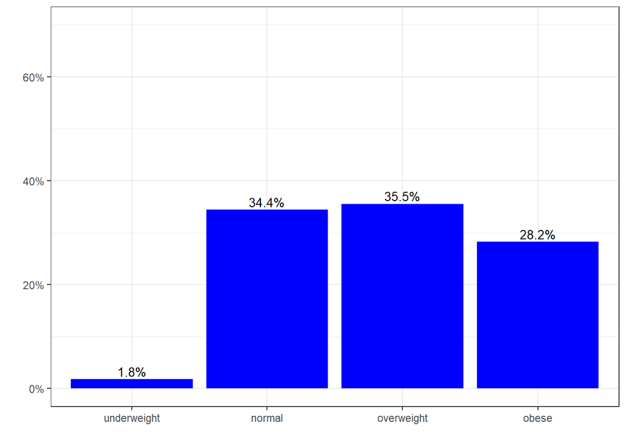

```
## $Age_est
##     quantile ci.2.5 ci.97.5       se
## 0.5       47     47      52 1.275339
##
## attr(,"hasci")
## [1] TRUE
## attr(,"class")
## [1] "newsvyquantile"
```

```
##           mean     SE
## Age_est 47.891 0.2398
```

```
## $BMI_est
##     quantile   ci.2.5  ci.97.5         se
## 0.5 26.75067 26.57497 26.87377 0.07621276
##
## attr(,"hasci")
## [1] TRUE
## attr(,"class")
## [1] "newsvyquantile"
```

```
##   Ethnicity      Freq       Prop
## 1     Asian  834.9203 0.10508303
## 2     Black  250.7492 0.03155929
## 3     Mixed  154.1919 0.01940658
## 4     Other   81.8804 0.01030546
## 5     White 6623.5972 0.83364564
```

```
##                    educ       Freq        Prop
## 1 A level or equivalent 2155.60739 0.271910989
## 2      Degree or higher 2405.73541 0.303462448
## 3               Foreign   78.46305 0.009897426
## 4         GCSE or lower 3287.81561 0.414729137
```

```
##                               work        Freq         Prop
## 1                     In Education  570.891980 0.0718524384
## 2 In Paid Employment/Self Employed 4636.187499 0.5835103454
## 3                Long term illness  315.972586 0.0397682952
## 4                          Missing    1.402071 0.0001764646
## 5                            Other   73.171804 0.0092093998
## 6                          Retired 1744.923152 0.2196159477
## 7                       Unemployed  128.398219 0.0161601940
## 8   Unpaid Work (including carers)  474.391678 0.0597069148
```

```
##   IMD_q     Freq      Prop
## 1     1 1552.426 0.1953883
## 2     2 1529.733 0.1925321
## 3     3 1587.487 0.1998011
## 4     4 1660.331 0.2089692
## 5     5 1615.361 0.2033093
```

```
##                     region      Freq       Prop
## 1            East Midlands  694.2830 0.08738243
## 2          East of England  882.2404 0.11103874
## 3                   London 1237.1096 0.15570256
## 4               North East  384.9314 0.04844744
## 5               North West 1040.2781 0.13092935
## 6               South East 1280.3047 0.16113909
## 7               South West  809.9587 0.10194137
## 8            West Midlands  824.4035 0.10375939
## 9 Yorkshire and the Humber  791.8295 0.09965963
```

## Gender

There is a statistically significant association between gender and excess weight prevalence, with women over-represented in the obese category and men in the overweight category.

```
##
##  Design-based Wald test of association
##
## data:  svychisq(~Sex + BMI_class, hse, statistic = "adjWald")
## F = 26.079, ndf = 3, ddf = 7934, p-value < 2.2e-16
```

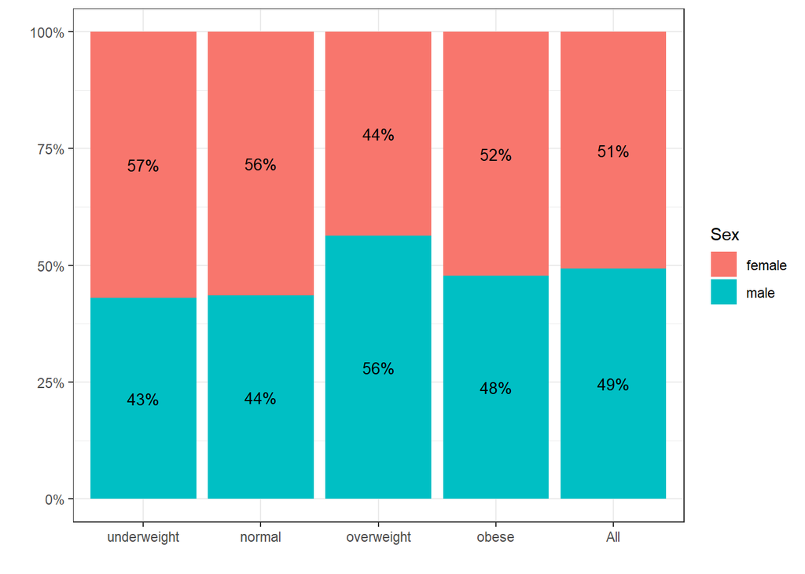

## Ethnicity

There is a statistically significant association between ethnicity and obesity with white people over-represented in the obese category.

```
##
##  Design-based Wald test of association
##
## data:  svychisq(~Ethnicity + BMI_class, hse, statistic = "adjWald")
## F = 5.2689, ndf = 12, ddf = 7925, p-value = 6.331e-09
```

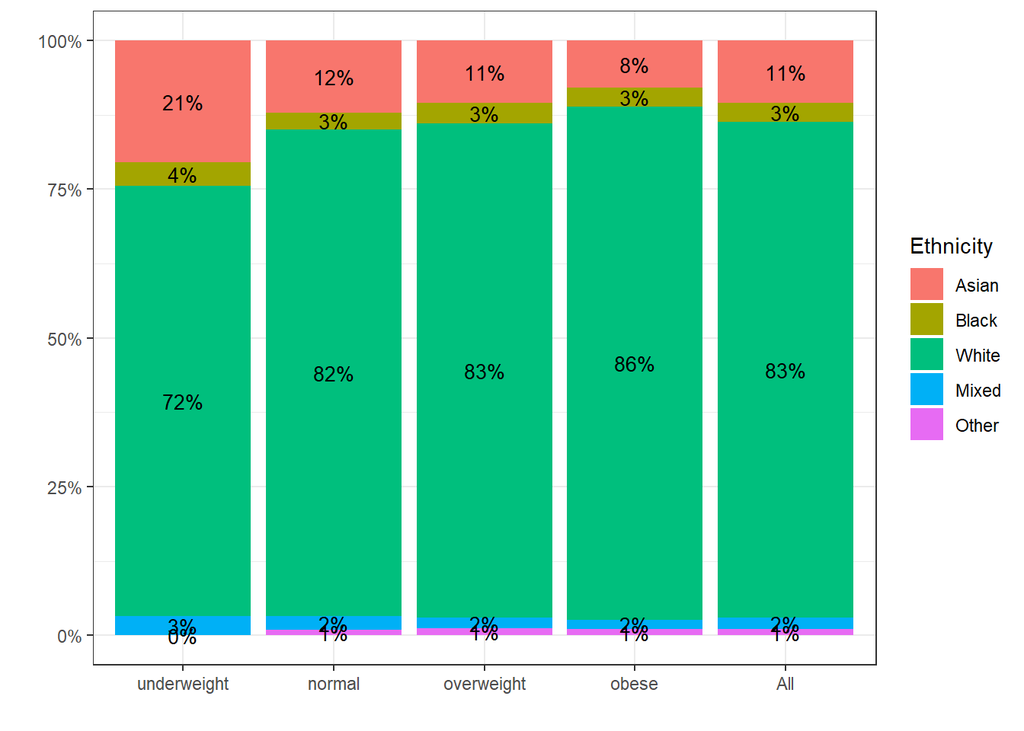

## Age group

There is a statistically significant association between age and obesity with people aged 50+ being over-represented in the obese and overweight categories.

```
##
##  Design-based Wald test of association
##
## data:  svychisq(~Age_group_2 + BMI_class, hse, statistic = "adjWald")
## F = 23.143, ndf = 15, ddf = 7922, p-value < 2.2e-16
```

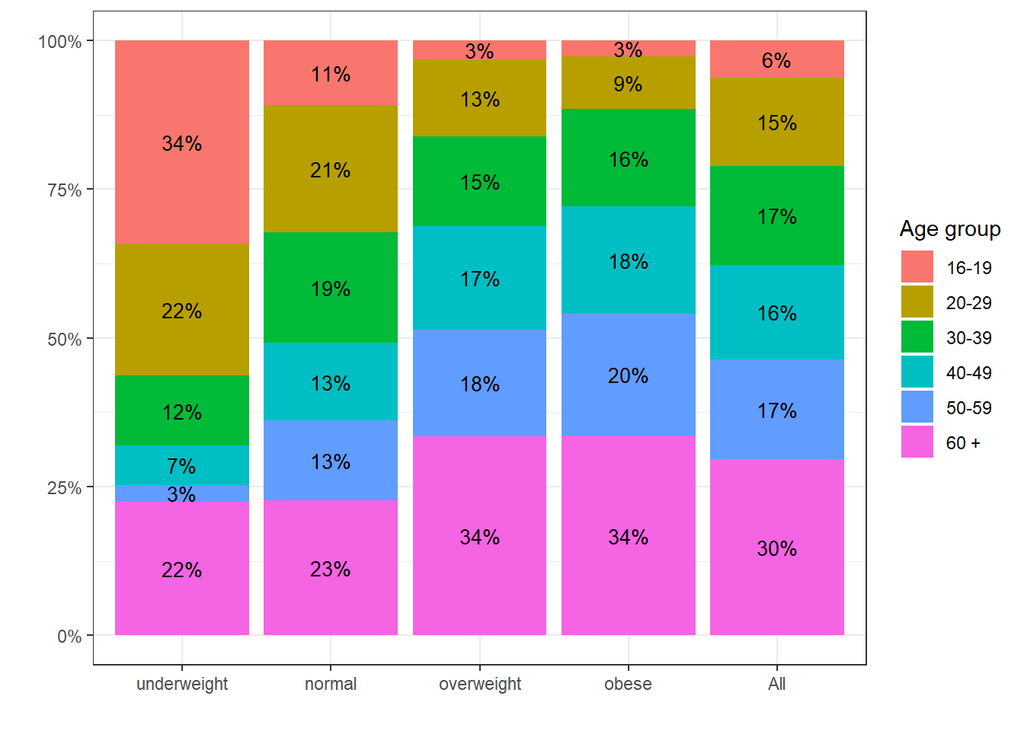

## Deprivation

```
##
##  Design-based Wald test of association
##
## data:  svychisq(~IMD_q + BMI_class, hse, statistic = "adjWald")
## F = 4.9354, ndf = 12, ddf = 7925, p-value = 3.374e-08
```

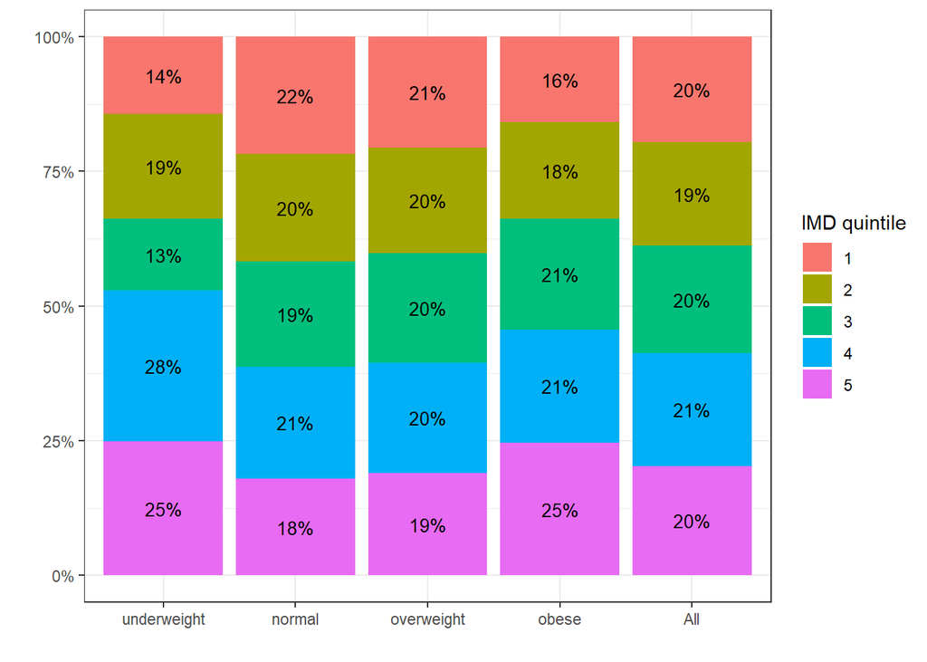

## Education

```
##
##  Design-based Wald test of association
##
## data:  svychisq(~educ + BMI_class, hse, statistic = "adjWald")
## F = 10.268, ndf = 9, ddf = 7928, p-value = 6.712e-16
```

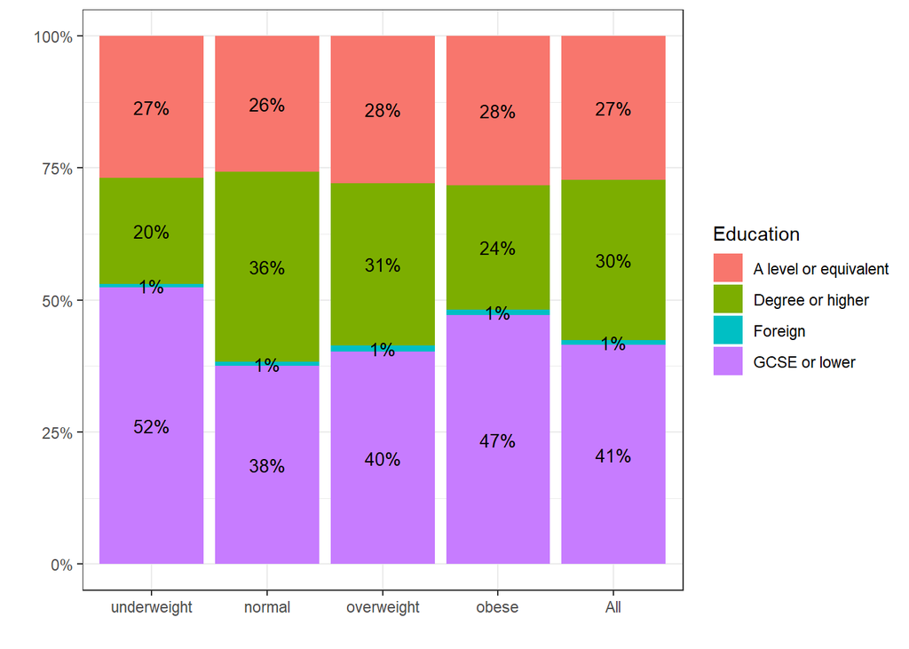

# Profiling Excess Weight

## Obese

To profile the obese population I divide it in three sections, based on the percentiles of the BMI distribution (below 25%, between 26% and 75% and above 75%).

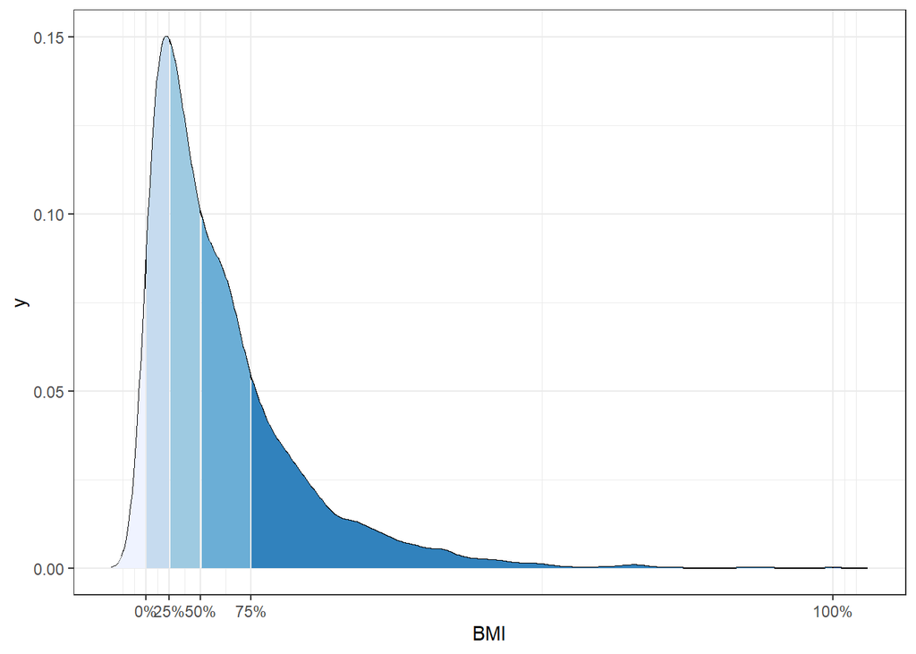

### Obese: the lower 25%

```
## $Age_est
##     quantile ci.2.5 ci.97.5       se
## 0.5       52     52      57 1.272908
##
## attr(,"hasci")
## [1] TRUE
## attr(,"class")
## [1] "newsvyquantile"
```

```
##           mean    SE
## Age_est 51.905 0.763
```

```
## $BMI_est
##     quantile   ci.2.5  ci.97.5         se
## 0.5 30.72607 30.63651 30.77349 0.03487185
##
## attr(,"hasci")
## [1] TRUE
## attr(,"class")
## [1] "newsvyquantile"
```

```
##   Ethnicity       Freq       Prop
## 1     Asian  57.286593 0.10156496
## 2     Black  13.752045 0.02438137
## 3     Mixed  10.400953 0.01844013
## 4     Other   3.521882 0.00624404
## 5     White 479.077496 0.84936950
```

```
##                    educ       Freq       Prop
## 1 A level or equivalent 154.669622 0.27512103
## 2      Degree or higher 142.010001 0.25260253
## 3               Foreign   7.318696 0.01301825
## 4         GCSE or lower 258.189255 0.45925820
```

```
##                               work        Freq        Prop
## 1                     In Education  15.6511802 0.027748402
## 2 In Paid Employment/Self Employed 340.6891372 0.604017020
## 3                Long term illness  19.3399057 0.034288244
## 4                          Missing   0.4523254 0.000801940
## 5                            Other   1.5973014 0.002831899
## 6                          Retired 141.9244887 0.251621779
## 7                       Unemployed   6.5733799 0.011654124
## 8   Unpaid Work (including carers)  37.8112502 0.067036592
```

```
##   IMD_q     Freq      Prop
## 1     1 106.6162 0.1890227
## 2     2 101.0022 0.1790696
## 3     3 124.3367 0.2204398
## 4     4 120.7758 0.2141266
## 5     5 111.3081 0.1973412
```

```
##                     region     Freq       Prop
## 1            East Midlands 55.59065 0.09855817
## 2          East of England 72.01958 0.12768547
## 3                   London 77.85762 0.13803588
## 4               North East 29.94548 0.05309116
## 5               North West 59.62270 0.10570671
## 6               South East 86.26640 0.15294404
## 7               South West 55.19314 0.09785342
## 8            West Midlands 69.76372 0.12368600
## 9 Yorkshire and the Humber 57.77967 0.10243915
```

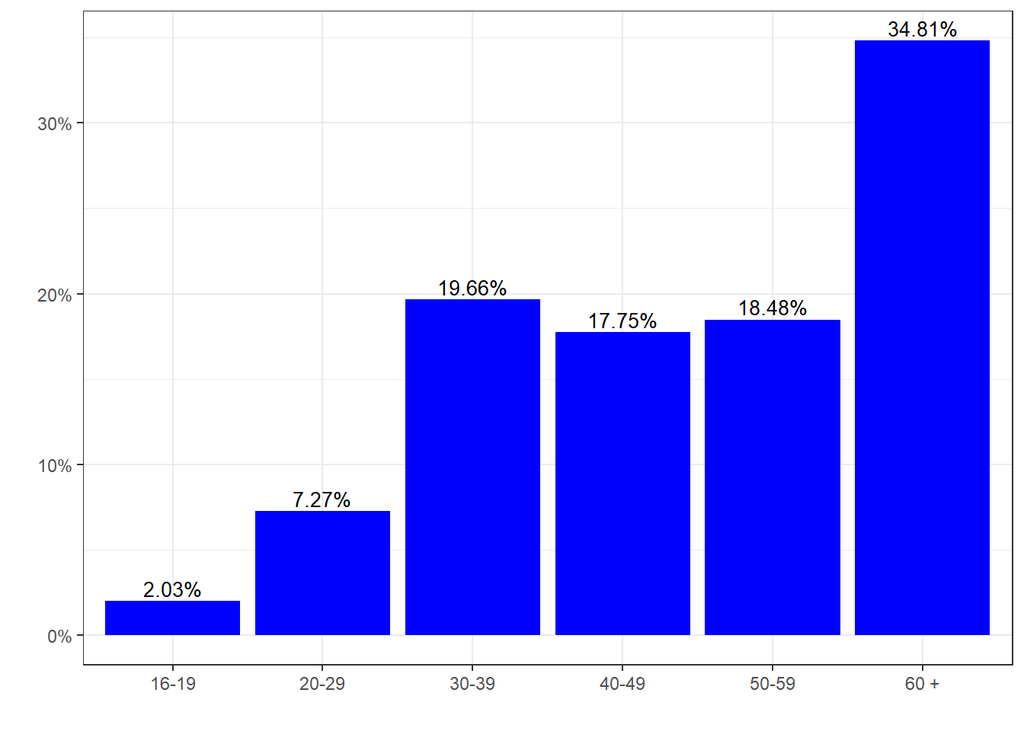

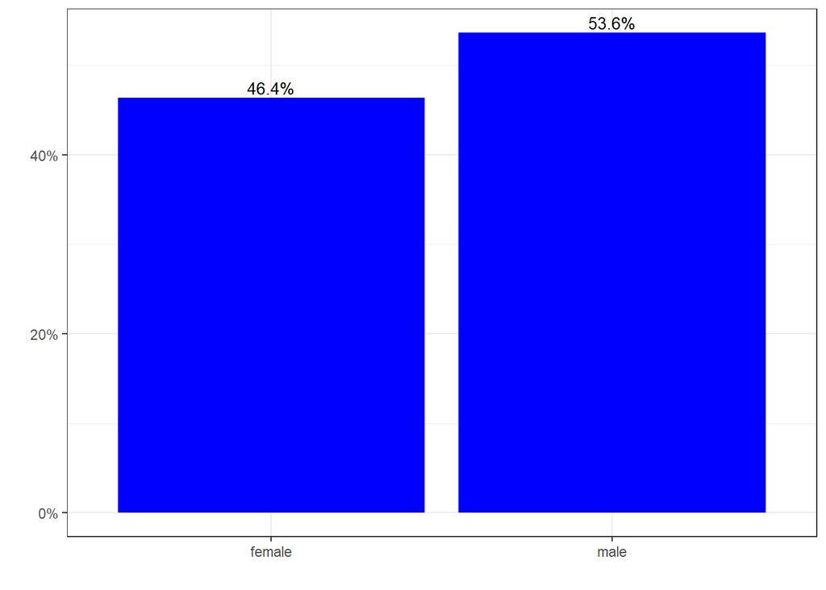

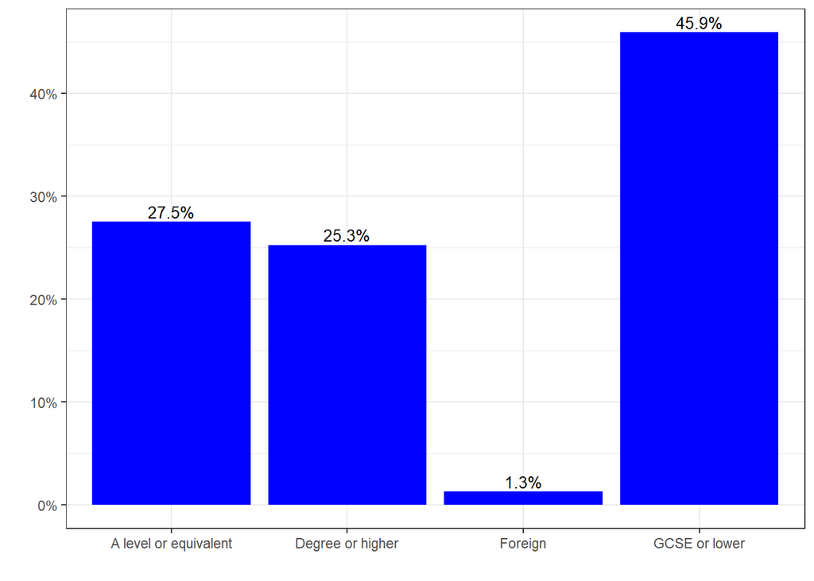

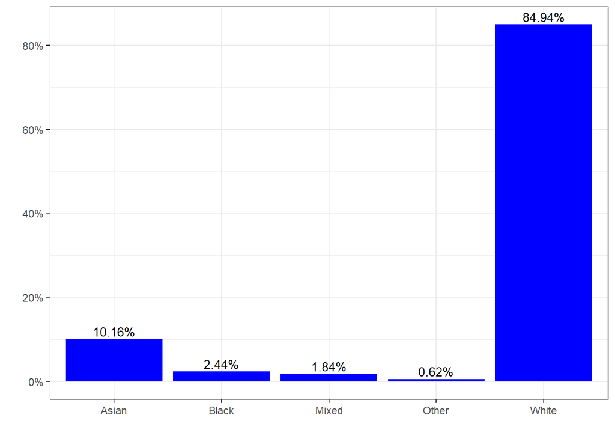

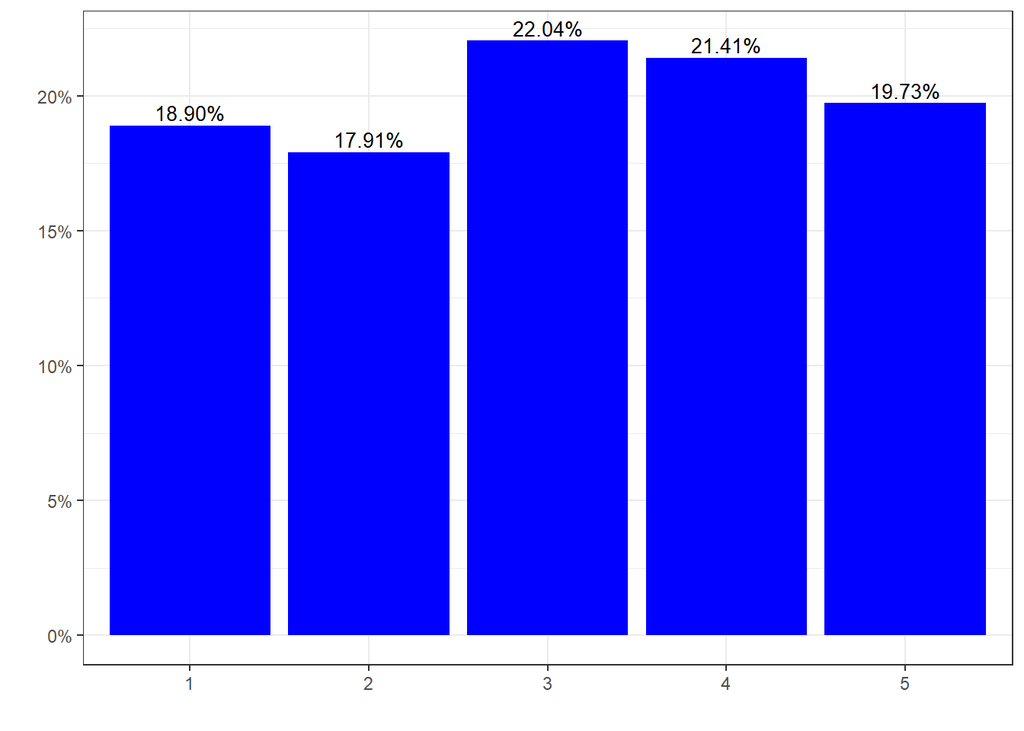

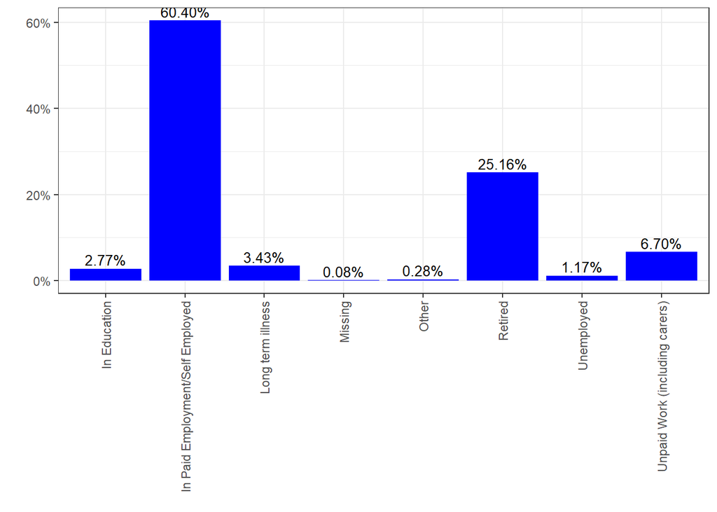

### Obese: the mid 50%

```
## $Age_est
##     quantile ci.2.5 ci.97.5      se
## 0.5       52     52      57 1.27422
##
## attr(,"hasci")
## [1] TRUE
## attr(,"class")
## [1] "newsvyquantile"
```

```
##           mean     SE
## Age_est 51.744 0.5466
```

```
## $BMI_est
##     quantile   ci.2.5  ci.97.5         se
## 0.5 33.47648 33.27876 33.64824 0.09415896
##
## attr(,"hasci")
## [1] TRUE
## attr(,"class")
## [1] "newsvyquantile"
```

```
##   Ethnicity       Freq        Prop
## 1     Asian  97.301325 0.086711350
## 2     Black  39.512474 0.035212058
## 3     Mixed  18.760806 0.016718937
## 4     Other   9.330657 0.008315137
## 5     White 957.223801 0.853042518
```

```
##                    educ      Freq       Prop
## 1 A level or equivalent 347.44020 0.31095334
## 2      Degree or higher 262.48135 0.23491655
## 3               Foreign  11.48008 0.01027449
## 4         GCSE or lower 495.93704 0.44385561
```

```
##                               work       Freq        Prop
## 1                     In Education  44.050255 0.039255962
## 2 In Paid Employment/Self Employed 666.909076 0.594324751
## 3                Long term illness  43.924415 0.039143818
## 4                            Other   5.739922 0.005115206
## 5                          Retired 272.318637 0.242680317
## 6                       Unemployed  20.422965 0.018200193
## 7   Unpaid Work (including carers)  68.763793 0.061279754
```

```
##   IMD_q     Freq      Prop
## 1     1 168.3553 0.1500320
## 2     2 228.5128 0.2036422
## 3     3 231.3611 0.2061805
## 4     4 238.2184 0.2122915
## 5     5 255.6814 0.2278538
```

```
##                     region      Freq       Prop
## 1            East Midlands 111.35230 0.09923306
## 2          East of England 111.23739 0.09913066
## 3                   London 135.83893 0.12105464
## 4               North East  61.98272 0.05523672
## 5               North West 184.02988 0.16400064
## 6               South East 146.60790 0.13065155
## 7               South West 125.42240 0.11177182
## 8            West Midlands 141.78973 0.12635777
## 9 Yorkshire and the Humber 103.86780 0.09256315
```

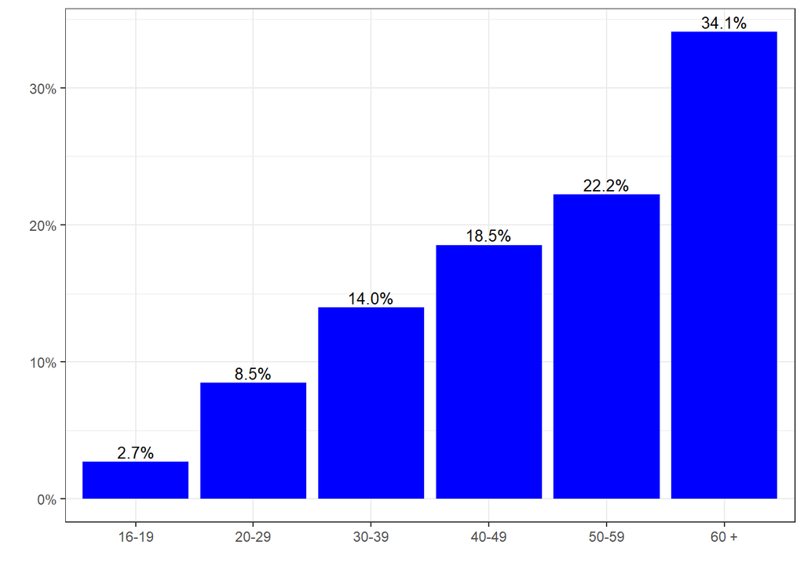

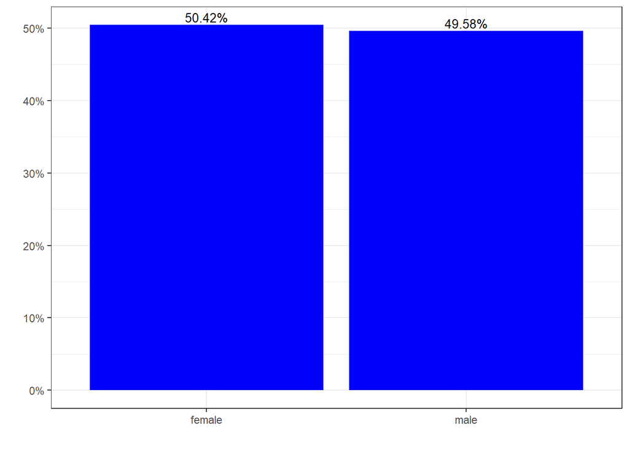

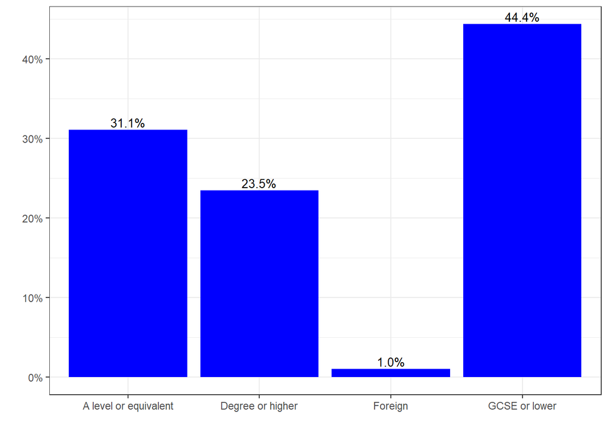

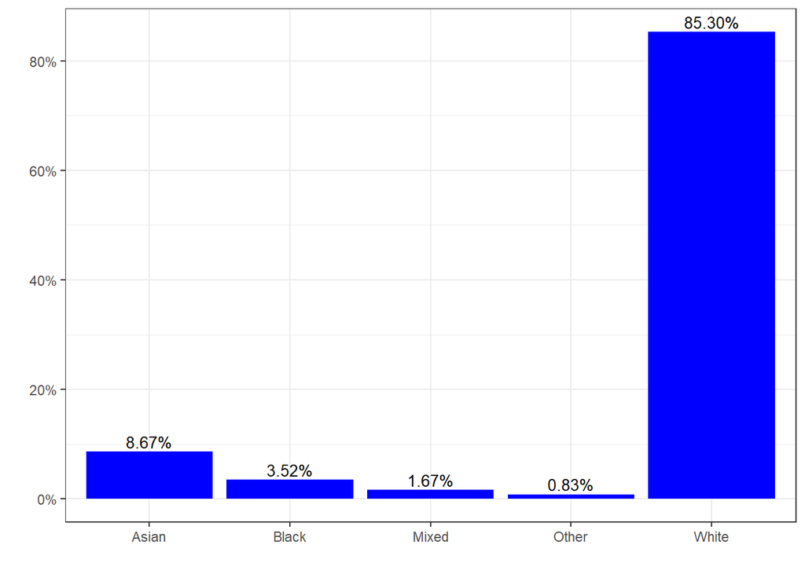

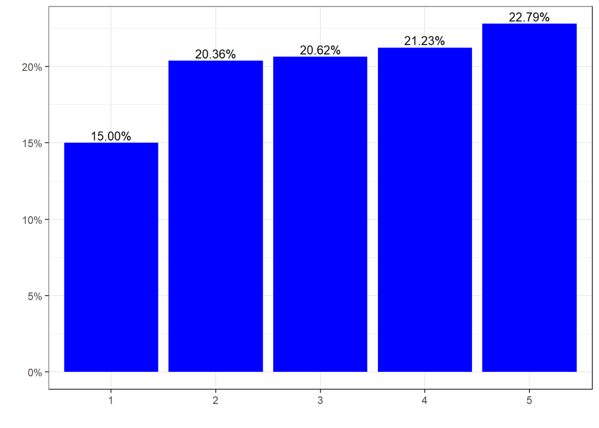

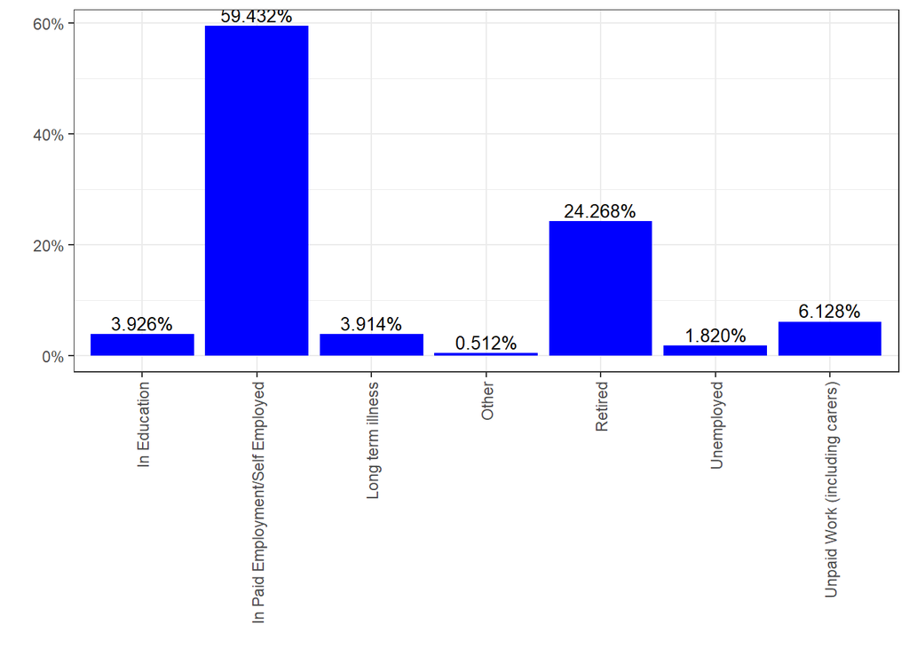

### Obese: the top 25%

```
## $Age_est
##     quantile ci.2.5 ci.97.5       se
## 0.5       52     52      57 1.272904
##
## attr(,"hasci")
## [1] TRUE
## attr(,"class")
## [1] "newsvyquantile"
```

```
##           mean     SE
## Age_est 49.517 0.7814
```

```
## $BMI_est
##     quantile   ci.2.5  ci.97.5        se
## 0.5 39.89009 39.63368 40.45341 0.2086861
##
## attr(,"hasci")
## [1] TRUE
## attr(,"class")
## [1] "newsvyquantile"
```

```
##   Ethnicity       Freq       Prop
## 1     Asian  23.570499 0.04233815
## 2     Black  16.989455 0.03051705
## 3     Mixed   6.494026 0.01166480
## 4     Other  11.093534 0.01992659
## 5     White 498.572570 0.89555341
```

```
##                    educ       Freq       Prop
## 1 A level or equivalent 129.817380 0.23318250
## 2      Degree or higher 121.965820 0.21907925
## 3               Foreign   4.192859 0.00753136
## 4         GCSE or lower 300.744023 0.54020689
```

```
##                               work       Freq        Prop
## 1                     In Education  14.044414 0.025227066
## 2 In Paid Employment/Self Employed 295.953015 0.531601111
## 3                Long term illness  60.623015 0.108893171
## 4                            Other   4.885931 0.008776279
## 5                          Retired 124.823626 0.224212544
## 6                       Unemployed   6.557398 0.011778627
## 7   Unpaid Work (including carers)  49.832684 0.089511202
```

```
##   IMD_q      Freq      Prop
## 1     1  81.86379 0.1470466
## 2     2  72.25989 0.1297957
## 3     3 104.21600 0.1871964
## 4     4 113.21009 0.2033519
## 5     5 185.17032 0.3326094
```

```
##                     region     Freq       Prop
## 1            East Midlands 59.97320 0.10772594
## 2          East of England 49.97424 0.08976547
## 3                   London 59.47597 0.10683280
## 4               North East 34.03958 0.06114307
## 5               North West 74.39387 0.13362885
## 6               South East 82.51894 0.14822340
## 7               South West 63.12462 0.11338664
## 8            West Midlands 66.93843 0.12023715
## 9 Yorkshire and the Humber 66.28124 0.11905668
```

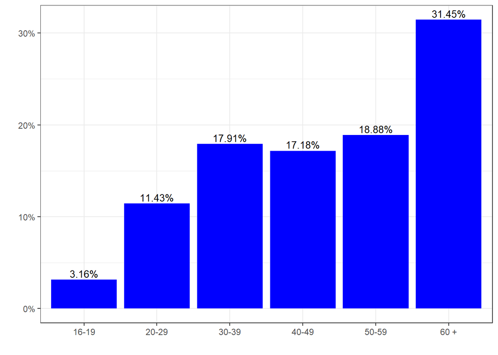

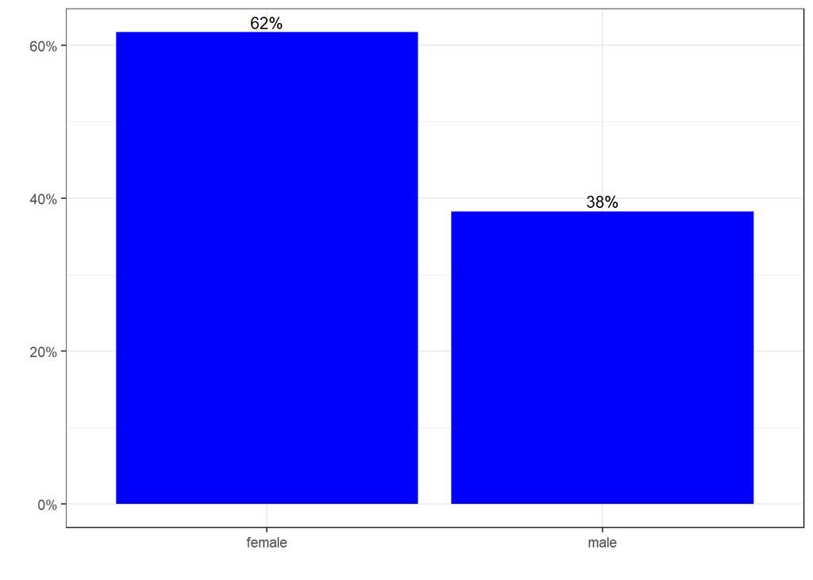

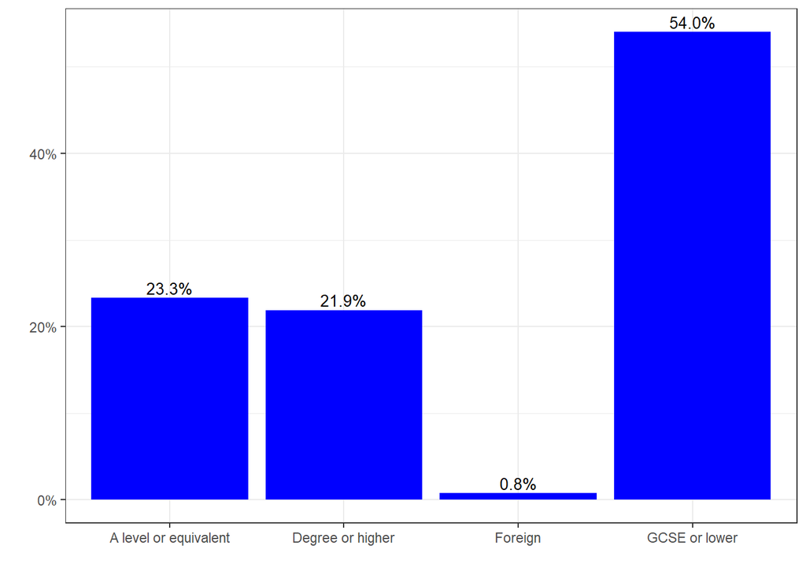

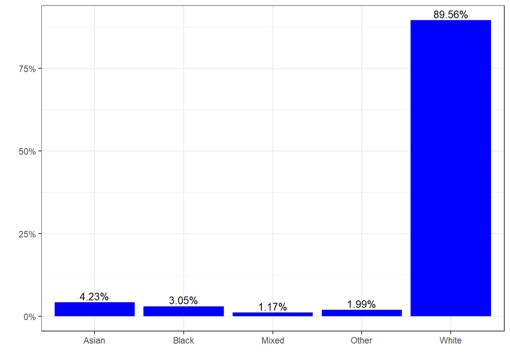

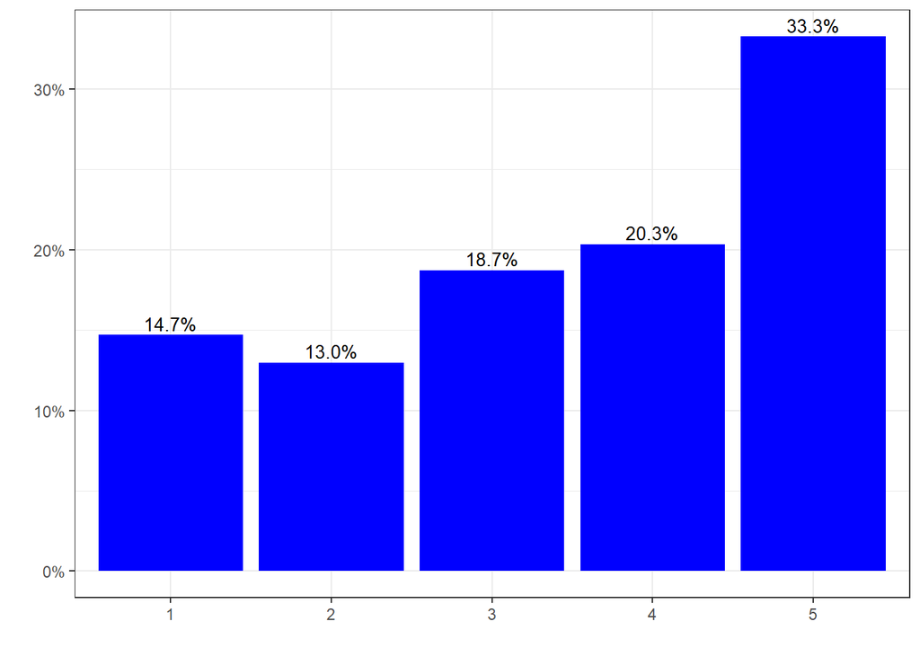

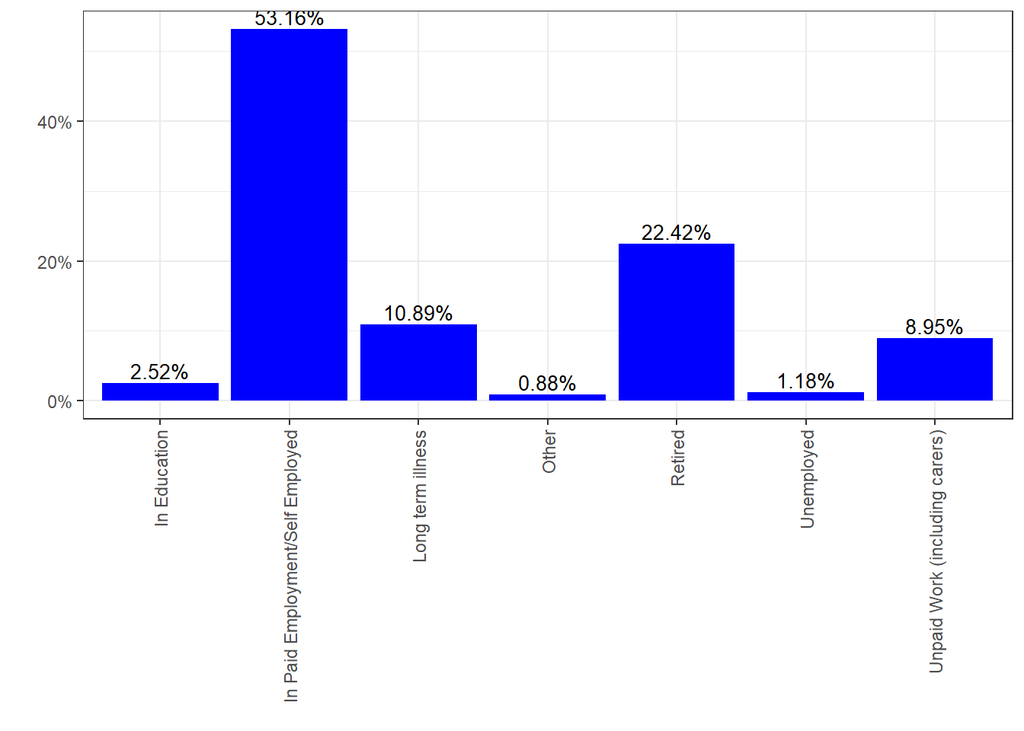